# About me

# About me

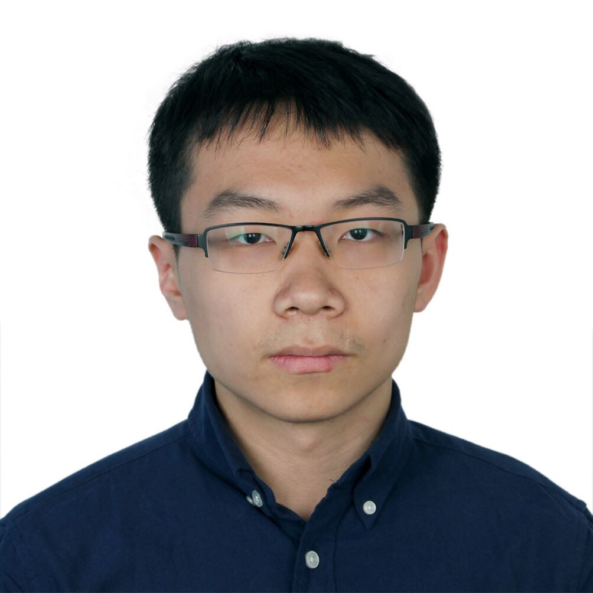

- Name: Ziyi Zhao
- Gender: Male
- Race: Asian
- Birthday: 10/06/1995
- Country: China
- City: Beijing
- Language skills: Chinese (proficient), English (proficient)
- Computing skills: Excel, R (more than 2 years), SAS (1 year)

## Personal Hobby

- Favorite animal: Husky, Shiba Inu, British Short Cat.
- Favorite video game: Assassin’s Creed, Call of Duty, Witcher 3.
- Favorite Anime: Demon Slayer, Natuto, Bleach, Fate Zero.
- Favorite Sport: English Soccer, Swimming.

# Degree and academic experience

## Degree

- High School Affliated to Renmin University, 2011-2014.
- Bachelor of Science, Acturial Science, Ohio Sate University, 2014-2018.
- Master of Public Health, Biostatistics, Columbia Univeristy, 2018-2020.

## Academic Experience

- Research-Based Studying at Ohio State University, 2015.
- Volunteering as Assistant Data Analyst at Clinical Laboratory Department in Beijing Aerospace General Hospital, 2017.
- Doing Summer Intern at the Biomedical Informatic Program in Ohio State Wexner Medical Center, 2018.
- Doing Summer practicum at the Database Shared Resource Center in the Herbert Irving Comprehensive Cancer Center, 2019.

To see more details, please see my Resume